# Project 2: SVD Analysis of Partisanship in U.S. Congress

Yi-Hsuan Wu, Cherry Pan

2/17/21

# Introduction

In this project, we explored U.S. Congress voting data from voteview.com. We used SVD analysis to examine the partisanship of U.S.Congress. The data that we examined were [90th House of Representatives](https://raw.githubusercontent.com/bryandmartin/STAT302/master/docs/Projects/project2_svd/house_90_raw.csv), [90th Senate](https://raw.githubusercontent.com/bryandmartin/STAT302/master/docs/Projects/project2_svd/senate_90_raw.csv), [116th House of Representatives](https://raw.githubusercontent.com/bryandmartin/STAT302/master/docs/Projects/project2_svd/house_116_raw.csv), [116th Senate](https://raw.githubusercontent.com/bryandmartin/STAT302/master/docs/Projects/project2_svd/senate_116_raw.csv). Note that in our analysis, blue represents the vote from Democrates, red represents the vote from Republicans, and green represents the vote from Independents. We hope this analysis can help people to better understand the U.S. partisanship from different aspects through visualizations and SVD analysis.

# Analysis

### Insight 1

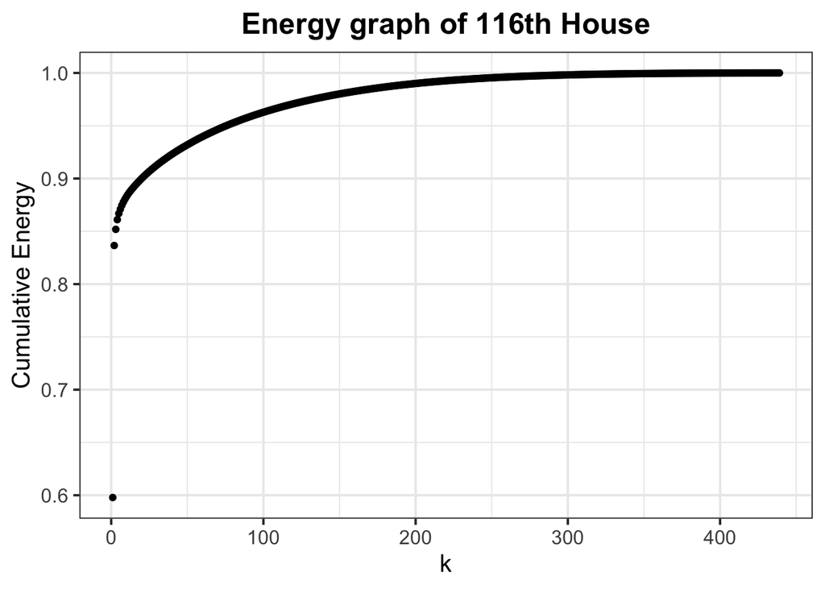

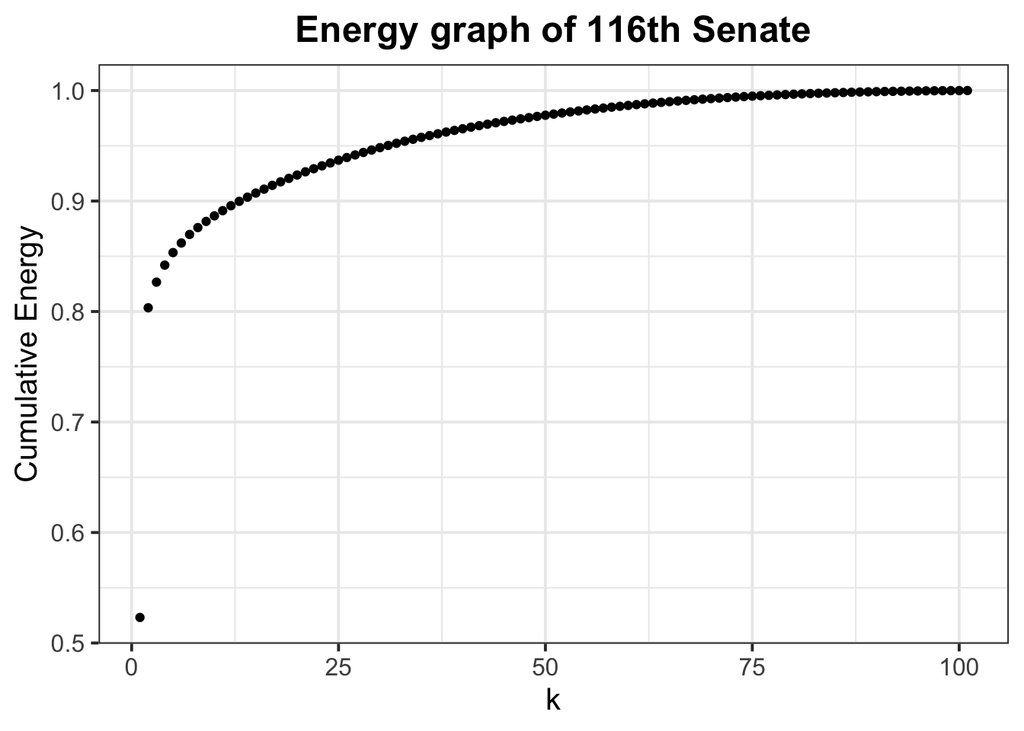

*Figure a (top)*  
*Figure b (below)*

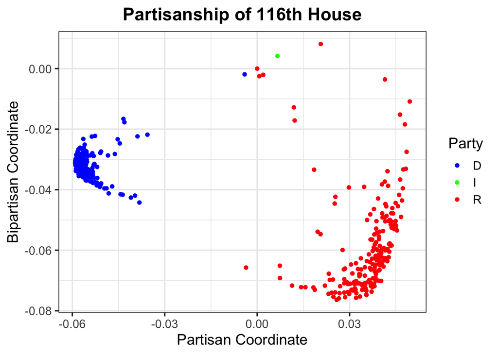

*Figure 1*

*Figure 1* is the mapping of partisanship of the 116th house representatives. The mapping was derived from the left singular vectors(U) from the Singular Value Decomposition(SVD) of 36 historical votings of the members of the 116th house of representative(Jan 2019-Jan 2021). When analyzing the data sets, I converted all the “NA” values to 0, assuming “present” for the voting. SVD is defined as
$$\mathbf{X} = \mathbf{U}\mathbf{D}\mathbf{V}^T.$$
The left singular vectors U, in general term, maps n observations to p “concepts”. It’s also noticed that we used two coordinates for the mapping since for this data set, the two leading singular vectors(k) give an over 80% of the energy of the data. The energy of the matrix is defined as the sum of the squared singular values and measures how good the singular vectors approximate the data. *Figure a* and *Figure b* show that two coordinates, meaning k = 2, give an over 80% approximation to the voting matrix and congressional voting positions of 116th house and 116th senate. This is also true for the 90th house and 90th senate.

We can see that each party has a fairly strong voting pattern, and the voting pattern of each party splits distinctively from the middle of the graph. Voting patterns for a few republicans differ considerably from the majority of the party while only one of the democrats had a rather differing voting pattern. There is only one independent representative, (Justin Amash), and he voted quite differently from both of the parties.

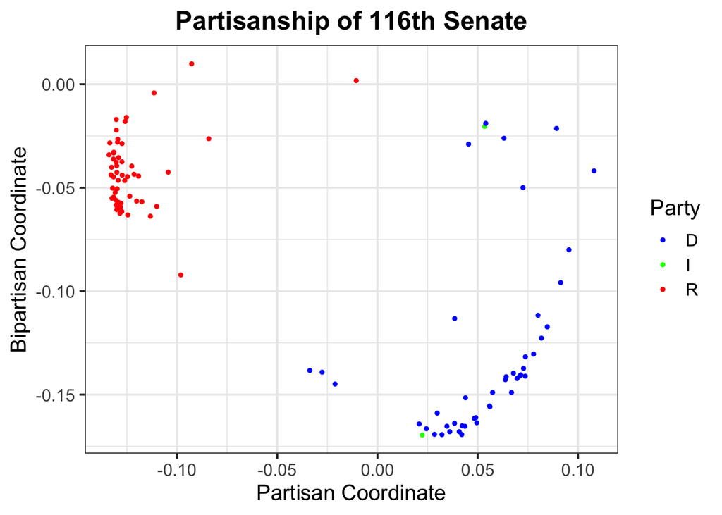

*Figure 2*  
This figure is a mapping of partisanship of the 116th senate. The mapping was obtained in the same fashion as *Figure 1*. Each party still has a fairly strong voting pattern, with the patterns splitting distinctively from the middle of the graph. However, for the 116th senate, voting pattern for the democrats differs considerably more than that for the republicans.

Then we want to examine the how the voting in 90th Congress and 116th Congress are different from each other, thus we also plot the partisanship of 90th House of Representative and Senate for a closer comparison.

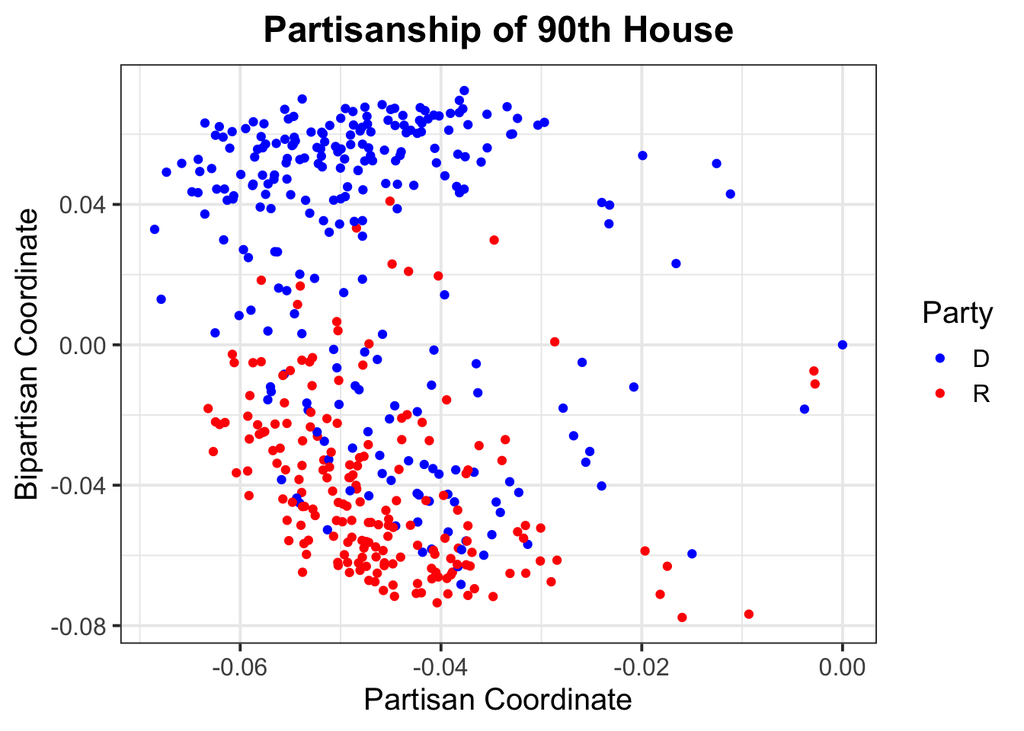

*Figure 3*

This figures shows the partisanship of 90th House of Representatives. One interesting obsersation is that there were only Democrats and Republicans parties in the House of representatives. Independents was not included in the 90th House. Unlike the voting for 116th the House of Represenatitives which shows a strong partisanship among parties, the voting points from these two parties cluster together, indicating a weaker partisanship.

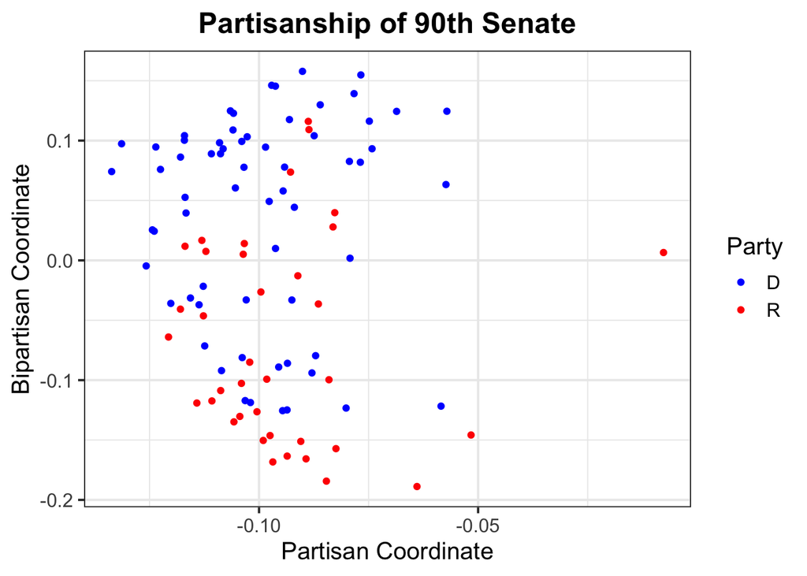

*Figure 4*

This figures shows the partisanship of 90th Senate. Similar to what we’ve observed in Figure 3, there was no representative of Independents Party in the Senate. From this plot, we can see that the voting point for Democrates and Republicans were all mixed together, implying that the views were not too polarized in the earlier time and people tended to have modest views.

### Insight 2

Extreme Partisanship in 116th House

| Partisan Coordinate | Bio Name | Extremity | Ranking |
| --- | --- | --- | --- |
| -0.004075214 | PELOSI, Nancy | 0.009489062 | Least Partisan |
| 0.049509880 | BIGGS, Andrew S. | 0.063074156 | Most Partisan |

*Table 1*
Since we observed a few “erratic” voting patterns in both partisanship mappings for 116th house of representatives and 116th senate, we wonder who had the most extreme voting patterns. Extremity is calculated as taking the absolute values of the individual’s partisan coordinate(x) minus the mean of the entire partisan coordinate($\mu_x$), simply
$$|x - \mu_x|.$$
The least partisan means it has smallest absolute value, and vice versa. The least partisan member of the 116th house is Pelosi while the most partisan individual is Biggs. Pelosi is a democrat. On the mapping of partisanship of the 116th house representatives, she is the “blue point” in the upper middle part of the graph. Biggs is a republican. On the mapping, he is represented by the right- most red point.

Extreme Partisanship in 116th Senate

| Partisan Coordinate | Bio Name | Extremity | Ranking |
| --- | --- | --- | --- |
| -0.03375242 | MANCHIN, Joe, III | 0.007720652 | Least Partisan |
| 0.10802608 | MARKEY, Edward John | 0.149499154 | Most Partisan |

*Table 2*  
For the 116 senate, the least partisan individual is Manchin, and the most is Markey. Both of them are democrats. Manchin, on the mapping, is represented by a blue dot in the bottom-middle part of the graph. Markey is the right-most blue dot in the graph. Such observation is predictable since the voting pattern of 116th senate is somewhat spread-out, instead of clustering as in the 116 house.

### Insight 3

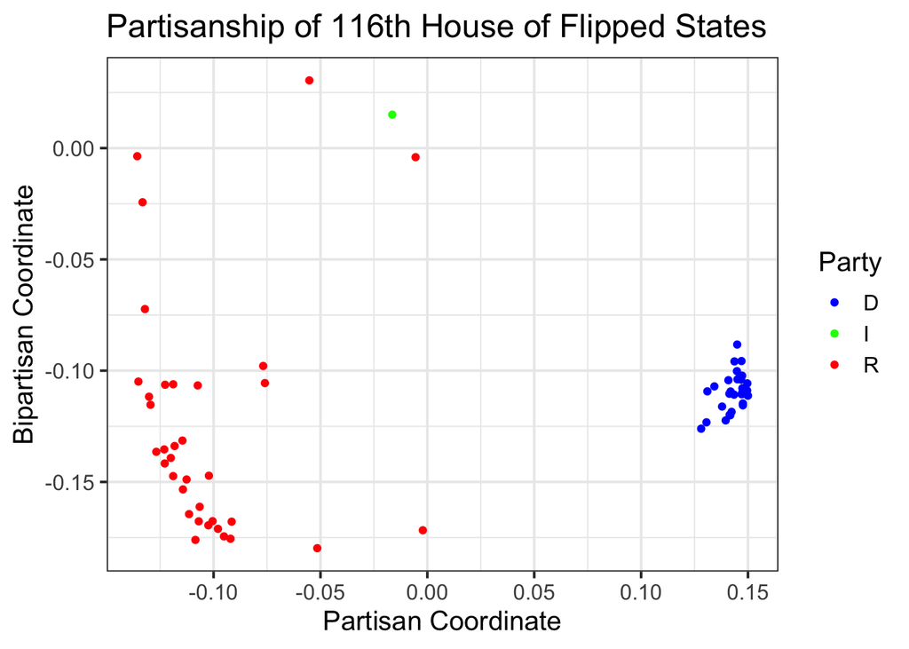

*Figure 5*  
In the last presidential election in 2020, 5 swing states flipped from red to blue. They are Arizona, Georgia, Michigan, Pennsylvania and Wisconsin. Hence, we’re intrigued by the voting pattern of the house and want to see if there’s a pattern associated with the flipping. We filtered the members from these five states and created partisan mapping for 116th house in the same fashion as did in *Figure 1* and *Figure 2*.

*Figure 5* shows that the voting pattern for the republicans differs considerably more than that for the democrats and is somewhat spread-out. This could imply that republicans in these five states may have voted differently in last election from most republicans as they didn’t vote vastly similarly as the majority of the party in the 36 votings.

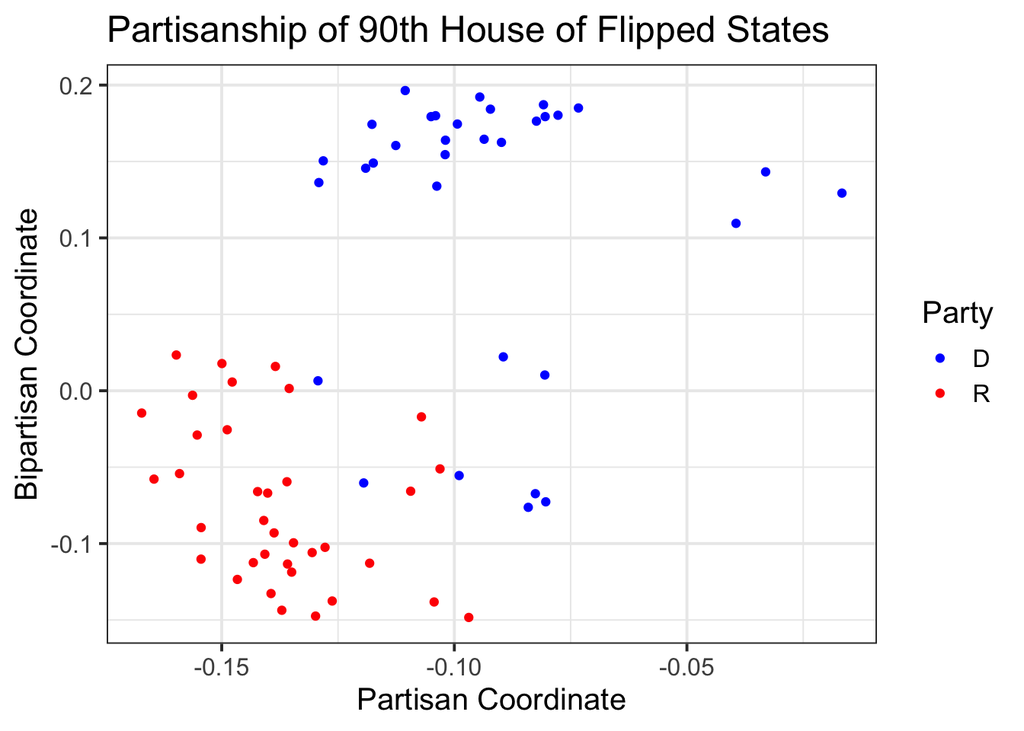

*Figure 6*

W also mapped out the partisanship of the 90th house (1967-1969) of the five flipped states, in the same way as before. From the graph, it’s observed that there’s no distinctive clustering that could indicate a partisanship. However, voting pattern for republicans is much more clustered than that for the democrats. Interestingly, the elected president of 1968, Nixon, is a republican.

From *Figure 5* and *Figure 6*, there may be an evidence that presidential election may have an association with strong partisan voting pattern in these five swing states.